# Linear Regression R

## 3. Data loading

```r
#install.packages("NHANES")
library(NHANES)
data(NHANES)

SMOKERS = NHANES %>%
  select(BMI, Age, SmokeNow, PhysActive) %>%
  filter(Age >= 18 & Age <= 70)
```

## 4. Data Exploration

```r
# Check for missing values in the selected data
missing_values <- SMOKERS %>%
  summarise(across(everything(), ~ sum(is.na(.))))

print(missing_values)
```

```
## # A tibble: 1 × 4
##     BMI   Age SmokeNow PhysActive
##   <int> <int>    <int>      <int>
## 1    47     0     3868          0
```

## 5. Handling Missing Data

We handle missing data to avoid bias, loss of information, and poor model performance, ensuring accurate and reliable analysis.

```r
# Remove rows with missing or non-finite values
SMOKERS <- SMOKERS %>%
  filter(!is.na(BMI) & !is.na(Age) & !is.na(SmokeNow) & !is.na(PhysActive))

# Confirm data cleaning
print(nrow(SMOKERS))  # Remaining rows after cleaning
```

```
## [1] 2779
```

## 6. Train - Test Split

Splitting the data into **training (75%) and testing (25%) sets** helps evaluate the model’s performance on unseen data. The training set is used to build the model, while the test set assesses its ability to generalize. This technique prevents **overfitting**, ensuring the model performs well on new data rather than just memorizing patterns from the training set.

```r
# Set seed for reproducibility
set.seed(123)

# Add the 'id' column to the original dataset (SMOKERS)
SMOKERS <- SMOKERS %>% mutate(id = row_number())

# Split the data into 75% training and 25% testing
SMOKERS_split <- SMOKERS %>%
  sample_frac(0.75)  # 75% for training data

# The remaining 25% will be for testing
test_data <- anti_join(SMOKERS, SMOKERS_split, by = "id")  # Join using 'id' column
train_data <- SMOKERS_split
```

## 7. Exploratory Data Analysis

In EDA, we use visualizations like histograms, box plots, and scatter plots to assess data distribution, relationships, and patterns, guiding analysis decisions.

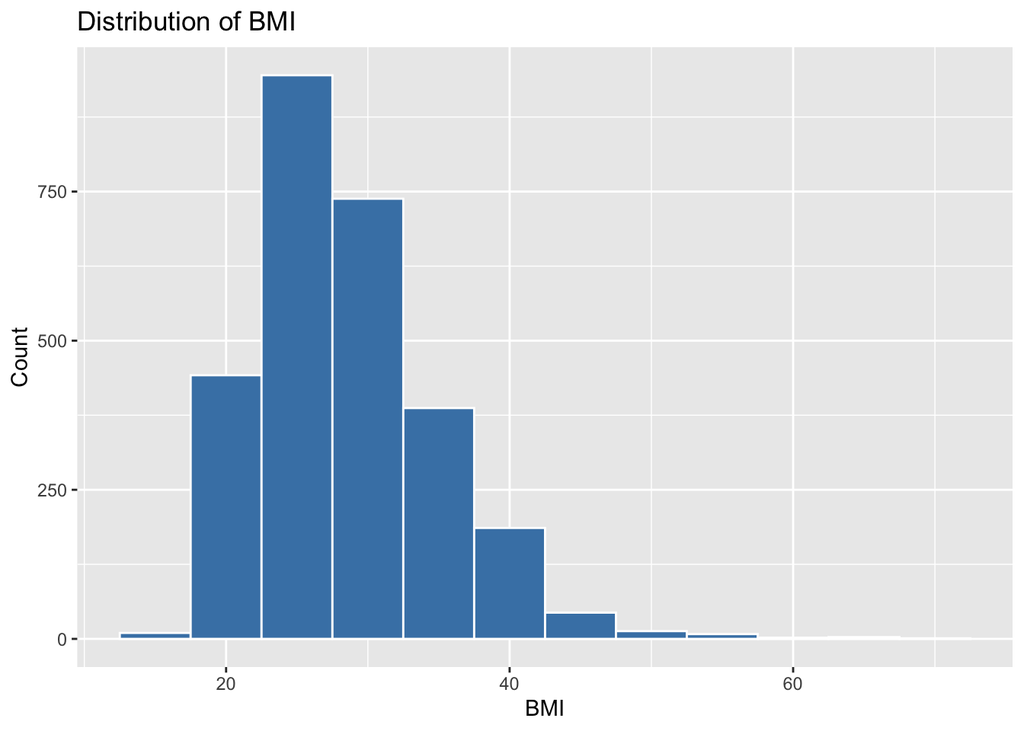

```r
# Plot the distribution of BMI
library(ggplot2)

ggplot(SMOKERS, aes(x = BMI)) +
  geom_histogram(fill = "steelblue", binwidth = 5, color = "white") +
  labs(title = "Distribution of BMI", x = "BMI", y = "Count")
```